# Сетевые технологии

Лабораторная работа №6

Элсаиед Адел

Российский университет дружбы народов, Москва, Россия

21 января 2026

# Цели и задачи работы

## Цель лабораторной работы

Настройка адресации **IPv4** и **IPv6** в среде **GNS3** и исследование режима **двойного стека**: - построение топологии с двумя подсетями IPv4 и IPv6 - настройка адресации на оконечных узлах и маршрутизаторах **FRR** (IPv4) и **VyOS** (IPv6) - проверка связности `ping` и `trace` - анализ трафика **ARP**, **ICMP**, **ICMPv6** в Wireshark - проверка изоляции подсетей IPv4 и IPv6 (кроме Dual Stack Server)

# Ход выполнения работы

## Топология сети и именование устройств

- Размещены устройства и выполнены соединения согласно топологии
- Принята схема именования:
  - коммутаторы: `msk-elsaiedadel-sw-0x`
  - маршрутизаторы: `msk-elsaiedadel-gw-0x`
  - VPCS: `PCx-elsaiedadel`
- Включён захват трафика на линии **Dual Stack Server ↔︎ ближайший коммутатор**

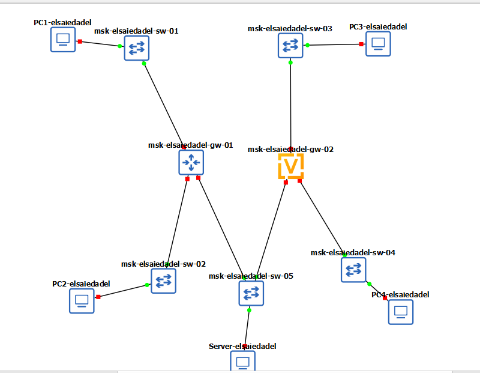

Топология сети (IPv4 + IPv6 + Dual Stack Server)

## IPv4-адресация на PC1

- Назначен адрес `172.16.20.10/25`
- Шлюз по умолчанию `172.16.20.1`
- Конфигурация сохранена

[figure not shown]

Настройка IPv4 на PC1

## IPv4-адресация на PC2

- Назначен адрес `172.16.20.138/25`
- Шлюз по умолчанию `172.16.20.129`
- Конфигурация сохранена

[figure not shown]

Настройка IPv4 на PC2

## IPv4-адресация на Dual Stack Server

- Назначен адрес `64.100.1.10/24`
- Шлюз по умолчанию `64.100.1.1`
- Конфигурация сохранена

[figure not shown]

Настройка IPv4 на сервере

## Настройка FRR (msk-elsaiedadel-gw-01)

- Установлен `hostname: msk-elsaiedadel-gw-01`
- Назначены адреса на интерфейсы:
  - `eth0: 172.16.20.1/25`
  - `eth1: 172.16.20.129/25`
  - `eth2: 64.100.1.1/24`
- Интерфейсы включены, конфигурация сохранена

[figure not shown]

Конфигурация IPv4 на FRR

## Проверка конфигурации FRR

- Проверены текущие настройки и состояние интерфейсов
- Подтверждены корректные адреса и статус `up`

[figure not shown]

Просмотр running-config FRR

## Проверка интерфейсов FRR

- Подтверждён список интерфейсов и назначенные адреса

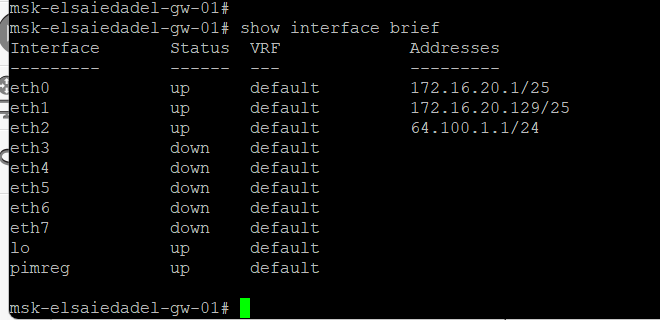

show interface brief FRR

## Проверка связности IPv4 (PC1 ↔︎ PC2)

- Выполнен `ping` между узлами PC1 и PC2
- Маршрут подтверждён средствами трассировки

[figure not shown]

Проверка связи PC1 ↔︎ PC2 (IPv4)

## Проверка доступности Dual Stack Server (IPv4)

- С PC2 выполнен `ping` до `64.100.1.10`
- Подтверждена корректная маршрутизация через FRR

[figure not shown]

Проверка связи PC2 → Dual Stack Server (IPv4)

## IPv6-адресация на PC3

- Назначен адрес `2001:db8:c0de:12::a/64`
- Конфигурация сохранена

[figure not shown]

Настройка IPv6 на PC3

## IPv6-адресация на PC4

- Назначен адрес `2001:db8:c0de:13::a/64`
- Конфигурация сохранена

[figure not shown]

Настройка IPv6 на PC4

## IPv6-адресация на Dual Stack Server

- Назначен адрес `2001:db8:c0de:11::a/64`
- Конфигурация сохранена

[figure not shown]

Настройка IPv6 на сервере

## Установка и первичная настройка VyOS (msk-elsaiedadel-gw-02)

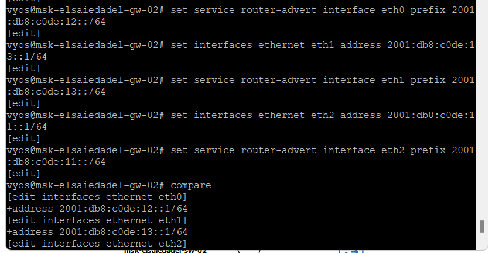

## Назначение IPv6 на интерфейсы VyOS и Router Advertisement

- `eth0: 2001:db8:c0de:12::1/64` + RA для `2001:db8:c0de:12::/64`
- `eth1: 2001:db8:c0de:13::1/64` + RA для `2001:db8:c0de:13::/64`
- `eth2: 2001:db8:c0de:11::1/64` + RA для `2001:db8:c0de:11::/64`
- Выполнены `commit` и `save`, проверены интерфейсы

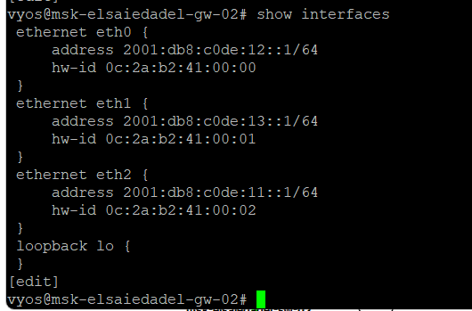

Просмотр интерфейсов VyOS (show interfaces)

## Проверка связности IPv6 (PC3)

- Выполнен `ping`/`trace` в IPv6-подсети
- Подтверждено прохождение через шлюз VyOS

[figure not shown]

Проверка IPv6-связности с PC3

## Проверка связности IPv6 (PC4)

- Выполнен `ping`/`trace` до узлов и сервера
- Подтверждена корректная маршрутизация в IPv6

[figure not shown]

Проверка IPv6-связности с PC4

## Проверка изоляции IPv4 и IPv6 подсетей

- Подтверждено, что узлы IPv4-подсети недоступны напрямую из IPv6-подсети и наоборот
- Dual Stack Server является единственным узлом, имеющим доступ к обеим подсетям

[figure not shown]

Проверка доступности обеих подсетей для Dual Stack Server

# Анализ трафика

## ICMP (IPv4) на линии Dual Stack Server ↔︎ switch

Из перехвата можно извлечь: - тип ICMP (Echo Request/Reply), идентификатор и номер последовательности - TTL (косвенно отражает число переходов) - признаки корректной доставки (наличие ответа)

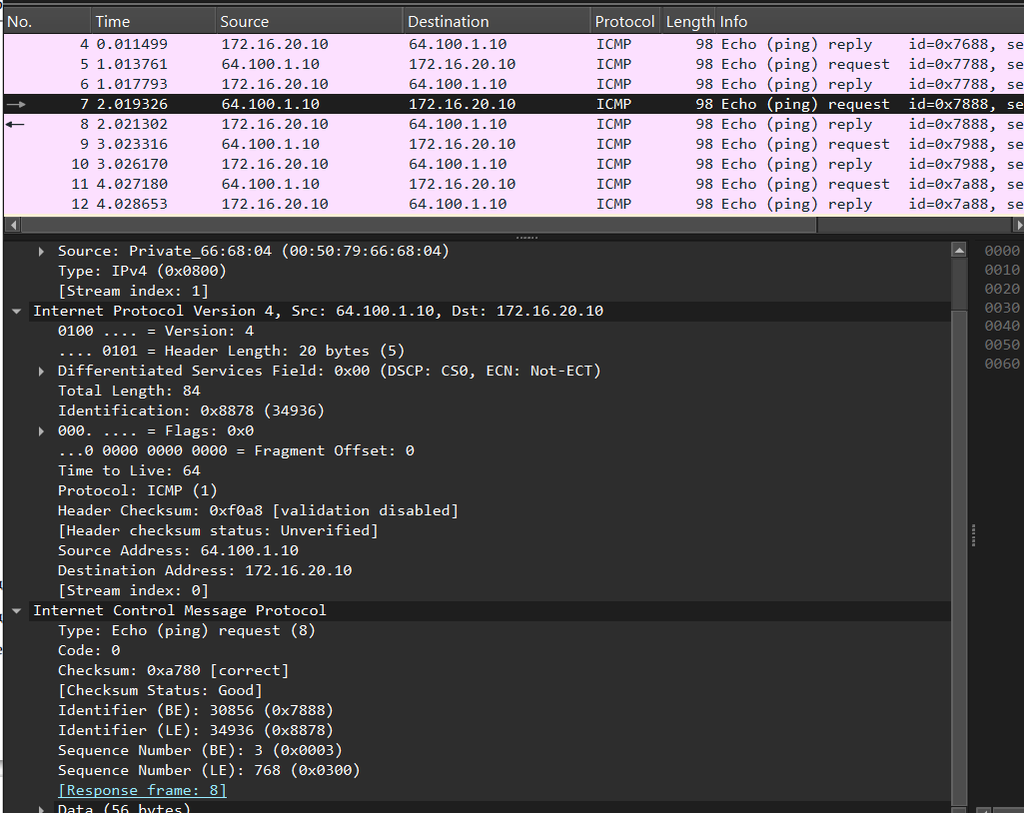

ICMP-трафик IPv4

## ICMPv6 на линии Dual Stack Server ↔︎ switch

Из перехвата можно извлечь: - тип ICMPv6 (Echo Request/Reply) - Hop Limit (аналог TTL) - идентификатор/sequence для сопоставления запросов и ответов

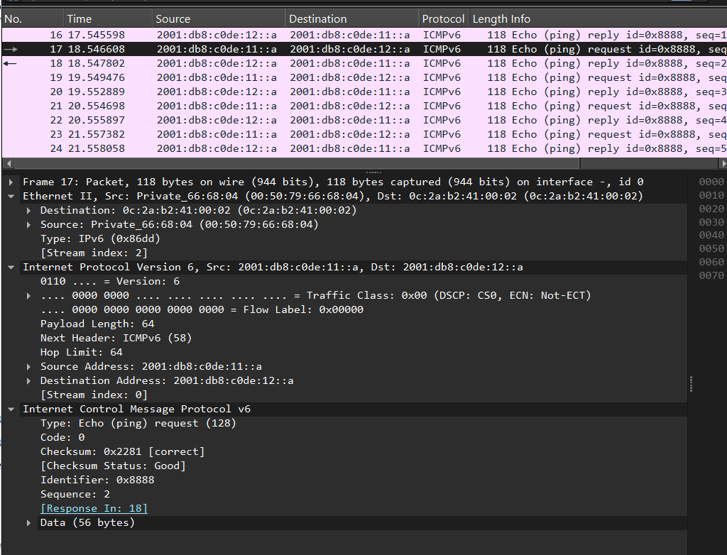

ICMPv6-трафик

## ARP на линии Dual Stack Server ↔︎ switch

Из перехвата можно извлечь: - соответствие IPv4 ↔︎ MAC (разрешение адресов) - запрашиваемый целевой IPv4-адрес (обычно адрес шлюза) - MAC/IP отправителя и формат ARP-запроса/ответа

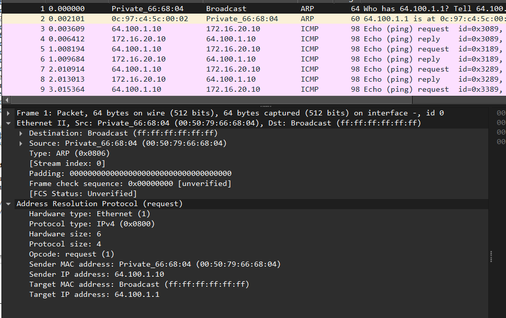

ARP-трафик

# Самостоятельное задание

## Топология с двумя локальными подсетями

- Маршрутизатор VyOS разделяет сеть на 2 подсети IPv4/IPv6
- Выполнено адресное планирование и настройка двойного стека

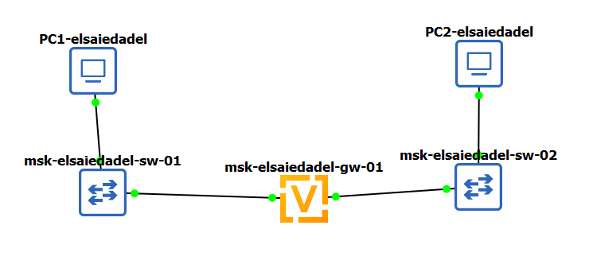

Топология самостоятельного задания

## Проверка конфигурации узлов (PC1)

- Назначены IPv4/IPv6 адреса согласно таблице адресации
- Проверены параметры `show ip` и `show ipv6`

[figure not shown]

Конфигурация на PC1 (IPv4/IPv6)

## Проверка конфигурации узлов (PC2)

- Назначены IPv4/IPv6 адреса согласно таблице адресации
- Проверены параметры `show ip` и `show ipv6`

[figure not shown]

Конфигурация на PC2 (IPv4/IPv6)

## Настройка VyOS для двух подсетей

- На интерфейсах маршрутизатора использованы минимальные адреса в подсети
- Настроены IPv4/IPv6 адреса и Router Advertisement
- Конфигурация применена и сохранена

[figure not shown]

Настройка VyOS (2 подсети)

## Проверка связности (IPv4) — ping/trace

- Выполнены проверки доступности между узлами разных подсетей
- Трассировка подтверждает прохождение через маршрутизатор

[figure not shown]

Проверка IPv4 (ping/trace)

## Проверка связности (IPv6) — ping/trace

- Выполнены проверки доступности по IPv6
- Трассировка подтверждает корректную маршрутизацию между префиксами

[figure not shown]

Проверка IPv6 (ping/trace)

# Итоги

## Заключение

- Построена и настроена модель сети с **IPv4** и **IPv6** в режиме **dual stack**
- Выполнена настройка адресации на VPCS и маршрутизаторах **FRR** и **VyOS**
- Проверена связность с помощью `ping` и `trace` для IPv4 и IPv6
- Подтверждена изоляция IPv4 и IPv6 подсетей (кроме сервера двойного стека)
- Выполнен захват и анализ трафика **ARP**, **ICMP**, **ICMPv6** в Wireshark
- Для самостоятельного задания выполнено адресное планирование и проверена работоспособность сети